# Interactions between factors with GAMMs

Michele Gubian

May 2023

# The “A” problem

Interactions between factors are common. In the example we develop in this section we deal with a 2 by 3 design, where a two-level `Category` interacts with a three-level `State`. With GAMMs implemented in the `mgcv` library there is no way to express such interaction as `Category * State`. This is by design. The “A” in GAMM stands for **additive**. This means that each effect is expressed as a sum; on the contrary, an interaction is a multiplicative effect. To be more precise, it is true that interactions between *covariates*, like time and trial, are taken care of by non-linear multi-dimensional tensor smooths. That is because the GAMM machinery is designed for modelling non-linear effects along one or more continuous variable through regularised curve or multidimensional surface fitting. But each of these uni- or multidimensional effects are then added together - that’s the “A” in GAMM. So the developers of `mgcv` decided not to introduce any automatic mechanism to create factor interaction terms, hence no use of the `*` symbol in model specification. This means we need to create interaction terms ourselves, and design our own contrasts.

## Example

Suppose we have realisations of a quantity `y` along the time axis. Each realisation has the form of a peak, and a `Category` with two levels, `low` and `high`, determines the general shape, i.e. a high/low peak. Suppose we run an experiment with participants going through 3 `States`: `BEFORE`, `DURING` and `AFTER` a certain experimental condition, such as imitiation, altered auditory feedback, etc.. For simplicity we will not consider subject, item, trial, or any other factor usually modelled by random terms. We have a number of hypotheses:

1. `BEFORE`: `high` curves higher than `low` curves
2. `DURING`: `high` curves get lower than their level `BEFORE`, `low` curves get higher than their level `BEFORE`, i.e. they move towards each other
3. `DURING`: `high` curves remain higher than `low` curves, i.e. they do not cross
4. `DURING`: `high` curves move more towards `low` curves than vice versa
5. `AFTER` : `high` resp. `low` curves do not get lower resp. higher than their level `DURING`, i.e. the effect is over
6. `AFTER` : `high` resp. `low` curves do not get higher resp. lower than their level `BEFORE`, i.e. no overshoot

Below an illustration of the data set.

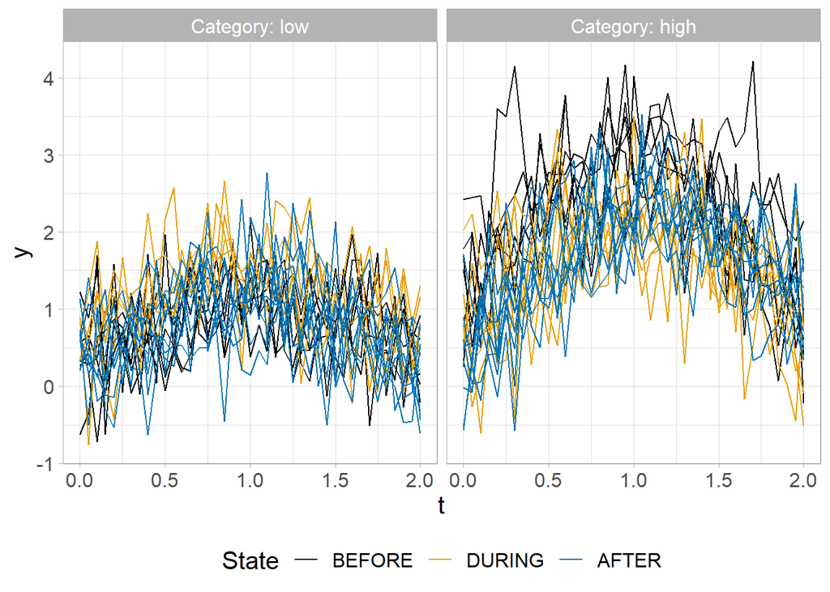

We are going to test hypotheses H1 to H4, while H5 and H6 are left as exercise.

### H1: `BEFORE`: `high` curves higher than `low` curves

First we need to create our own interaction term, as there is no way to express something like `Category * State` directly. Then we need to introduce convenient binary smooths that represent the smooth diffeences we are testing.

The interaction term is created as follows:

```r
curves$CategoryState <- interaction(curves$Category, curves$State)
curves %>% distinct(CategoryState)
```

```
## # A tibble: 6 x 1
##   CategoryState
##   <fct>
## 1 low.BEFORE
## 2 low.DURING
## 3 low.AFTER
## 4 high.BEFORE
## 5 high.DURING
## 6 high.AFTER
```

We then obtain smooth contrasts by creating one ordinary smooth per `State` and one corresponding binary smooth representing the difference between `high` and `low` at each `State`. The equation of the model is ($s =$ `State`, $c =$ `Category`, $(l, h) =$ `(low, high)`, $(B, D, A) =$ `(BEFORE, DURING, AFTER)`):

$$y_i = \beta_0 + \sum_{s \in \{D, A\}}
\beta_{s_i} \cdot I(s_i = s) + \\
\sum_{s \in \{B, D, A\}} f_{s_i}(t_i) \cdot I(s_i = s) +
\sum_{s \in \{B, D, A\}} b_{s_i, h}(t_i) \cdot I(s_i = s \cap c = h) +
\epsilon_i$$
Suppose a sample $i$ at time $t_i$ belongs to a curve of `Category` `low` ($c_i = l$) and `State` `BEFORE` ($s_i = B$). Then the the identity functions ‘switch on’ the following terms:

$$y_i = \beta_0 + f_B(t_i) + \epsilon_i$$
while if `State == BEFORE` but `Category == high`

$$y_i = \beta_0 + f_B(t_i) + b_{B,
h}(t_i) + \epsilon_i$$
and analogously for the other two states. This shows that the binary smooth $b_{B, h}(t_i)$ represents the difference between `high` and `low` for the `BEFORE` state. Remember that ordinary smooths like $f_B(t_i)$ are zero-centered, hence the whole effect is a combination of the intercept and the smooth itself. In this case, `BEFORE` is the control level for the intercept, thus only $\beta_0$ is present. On the contrary, binary terms are not zero-centered, hence $b_{B, h}(t_i)$ represents the whole difference `high - low` for the `BEFORE` `State`. We have also two other binary smooth terms which are not needed for H1, but may be used for other hypotheses. Note that if we were leaving out those terms from the model we would obtain different results, and the model itself would not be able to express each of the 6 combinations of `State` and `Category` with a unique set of terms - in other words, it would be the wrong model.

Intuitively this model setup is the application of the idea of binary smooths as contrasts, already illustrated on a case with only one difference, here applied separately to each level of `State`. The combination of fixed terms ($\beta$) and ordinary smooths ($f$) models the effect of `State` independently of `Category`, while each of the binary smooths ($b$) model the difference `high - low` specific for each level of `State`.

The corresponding GAM is expressed using `mgcv` as:

```r
# create binary variables
curves$IsBEFORE_high <- 1 * (curves$CategoryState == "high.BEFORE")
curves$IsDURING_high <- 1 * (curves$CategoryState == "high.DURING")
curves$IsAFTER_high  <- 1 * (curves$CategoryState == "high.AFTER")
# model
mod1 <- bam(y ~ State + s(t, by = State) + s(t, by = IsBEFORE_high) + s(t, by = IsDURING_high) + s(t, by = IsAFTER_high), data = curves)
summary(mod1)
```

```
##
## Family: gaussian
## Link function: identity
##
## Formula:
## y ~ State + s(t, by = State) + s(t, by = IsBEFORE_high) + s(t,
##     by = IsDURING_high) + s(t, by = IsAFTER_high)
##
## Parametric coefficients:
##             Estimate Std. Error t value Pr(>|t|)
## (Intercept)  0.73955    0.01236  59.839  < 2e-16 ***
## StateDURING  0.36954    0.01748  21.143  < 2e-16 ***
## StateAFTER   0.11337    0.01748   6.486 9.14e-11 ***
## ---
## Signif. codes:  0 '***' 0.001 '**' 0.01 '*' 0.05 '.' 0.1 ' ' 1
##
## Approximate significance of smooth terms:
##                      edf Ref.df      F p-value
## s(t):StateBEFORE   5.292  6.359  39.38  <2e-16 ***
## s(t):StateDURING   5.956  7.086  76.57  <2e-16 ***
## s(t):StateAFTER    5.686  6.789  60.17  <2e-16 ***
## s(t):IsBEFORE_high 7.064  8.157 903.98  <2e-16 ***
## s(t):IsDURING_high 4.584  5.421  83.50  <2e-16 ***
## s(t):IsAFTER_high  5.716  6.732 370.33  <2e-16 ***
## ---
## Signif. codes:  0 '***' 0.001 '**' 0.01 '*' 0.05 '.' 0.1 ' ' 1
##
## R-sq.(adj) =   0.56   Deviance explained = 56.2%
## fREML =  10382  Scale est. = 0.31312   n = 12300
```

The term `s(t):IsBEFORE_high`, i.e. $b_{B, h}(t_i)$, is significant, but we don’t know if this difference term is above or below zero, or combinations thereof. If H1 is supported, then we want to see a difference curve above the zero line.

Let’s plot the binary smooth:

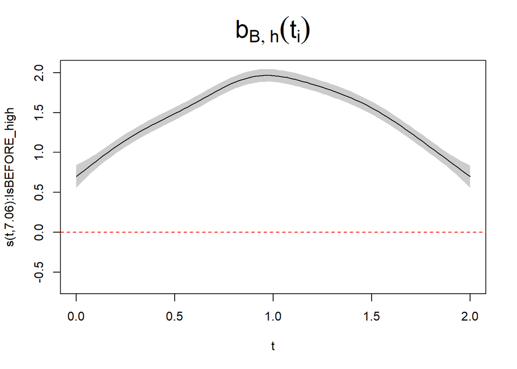

```r
# note: get_modelterm(mod1, select = 4) does not work with combinations of binary and factor smooths (!!)
# I have found an ugly workaround for that, ask me if interested.
# Or even better, let me know if there is an R library that works best in this case.
plot(mod1, select = 4, shade = TRUE, rug = FALSE, main = expression(b[list(B, h)](t[i])), cex.main=2)
abline(h=0, col='red', lty=2)
```

Yes $b_{B, h}(t_i)$ is clearly positive along the time axis, hence H1 is supported.

### H2: `DURING`: `high` lower than `BEFORE`, `low` higher than `BEFORE`

The setup is similar to the one for H1, except that now we need to model the difference `DURING - BEFORE` for each `Category` level.

$$y_i = \beta_0 + \beta_h \cdot I(c_i =
h) + \\
\sum_{c \in \{l, h\}} ( f_{c_i}(t_i) \cdot I(c_i = c) +
b_{c_i, D}(t_i) \cdot I(c_i = c \cap s = D) +
b_{c_i, A}(t_i) \cdot I(c_i = c \cap s = A) ) +
\epsilon_i$$
In this case the terms $b_{l, D}(t_i)$ and $b_{h, D}(t_i)$ represent the difference `DURING - BEFORE` for `low` and `high` respectively. We are using the convention whereby `BEFORE` is the default level, so the other binary smooths represent the differences `AFTER - BEFORE`, which we do not need for H2.

The model in `mgcv` is:

```r
# create binary variables
curves$IsDURING_low <- 1 * (curves$CategoryState == "low.DURING")
curves$IsAFTER_low  <- 1 * (curves$CategoryState == "low.AFTER")
# already created
# curves$IsDURING_high <- 1 * (curves$CategoryState == "high.DURING")
# curves$IsAFTER_high  <- 1 * (curves$CategoryState == "high.AFTER")
# model
mod2 <- bam(y ~ Category + s(t, by = Category) + s(t, by = IsDURING_low) + s(t, by = IsDURING_high) + s(t, by = IsAFTER_low) + s(t, by = IsAFTER_high), data = curves)
summary(mod2)
```

```
##
## Family: gaussian
## Link function: identity
##
## Formula:
## y ~ Category + s(t, by = Category) + s(t, by = IsDURING_low) +
##     s(t, by = IsDURING_high) + s(t, by = IsAFTER_low) + s(t,
##     by = IsAFTER_high)
##
## Parametric coefficients:
##              Estimate Std. Error t value Pr(>|t|)
## (Intercept)   0.73952    0.01236   59.83   <2e-16 ***
## Categoryhigh  1.44615    0.01748   82.74   <2e-16 ***
## ---
## Signif. codes:  0 '***' 0.001 '**' 0.01 '*' 0.05 '.' 0.1 ' ' 1
##
## Approximate significance of smooth terms:
##                      edf Ref.df      F p-value
## s(t):Categorylow   5.715  6.844  43.33  <2e-16 ***
## s(t):Categoryhigh  7.772  8.553 271.20  <2e-16 ***
## s(t):IsDURING_low  4.298  5.083  93.69  <2e-16 ***
## s(t):IsDURING_high 5.601  6.615 278.13  <2e-16 ***
## s(t):IsAFTER_low   3.672  4.320  11.87  <2e-16 ***
## s(t):IsAFTER_high  4.713  5.580 149.15  <2e-16 ***
## ---
## Signif. codes:  0 '***' 0.001 '**' 0.01 '*' 0.05 '.' 0.1 ' ' 1
##
## R-sq.(adj) =   0.56   Deviance explained = 56.2%
## fREML =  10379  Scale est. = 0.31315   n = 12300
```

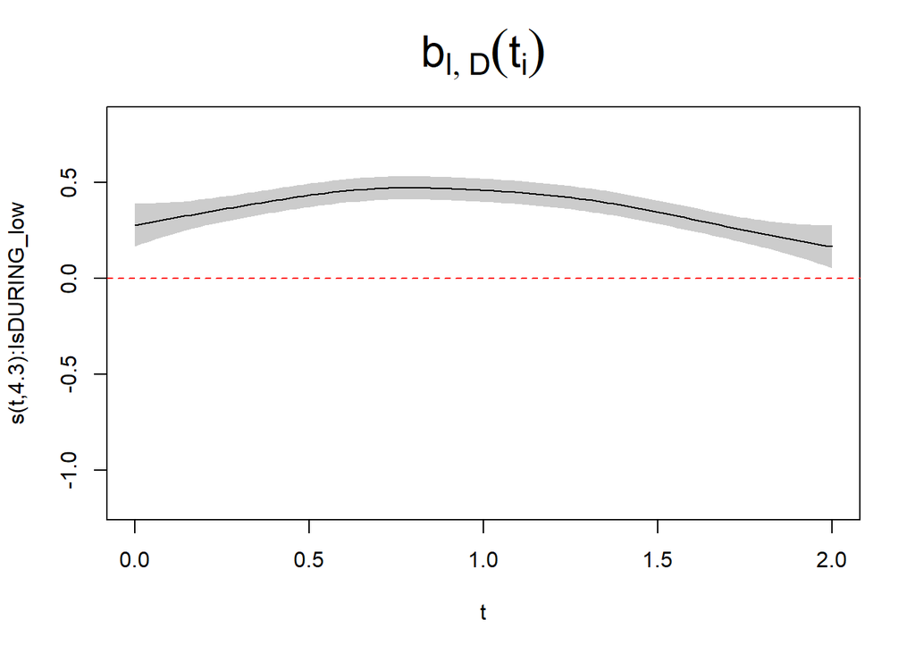

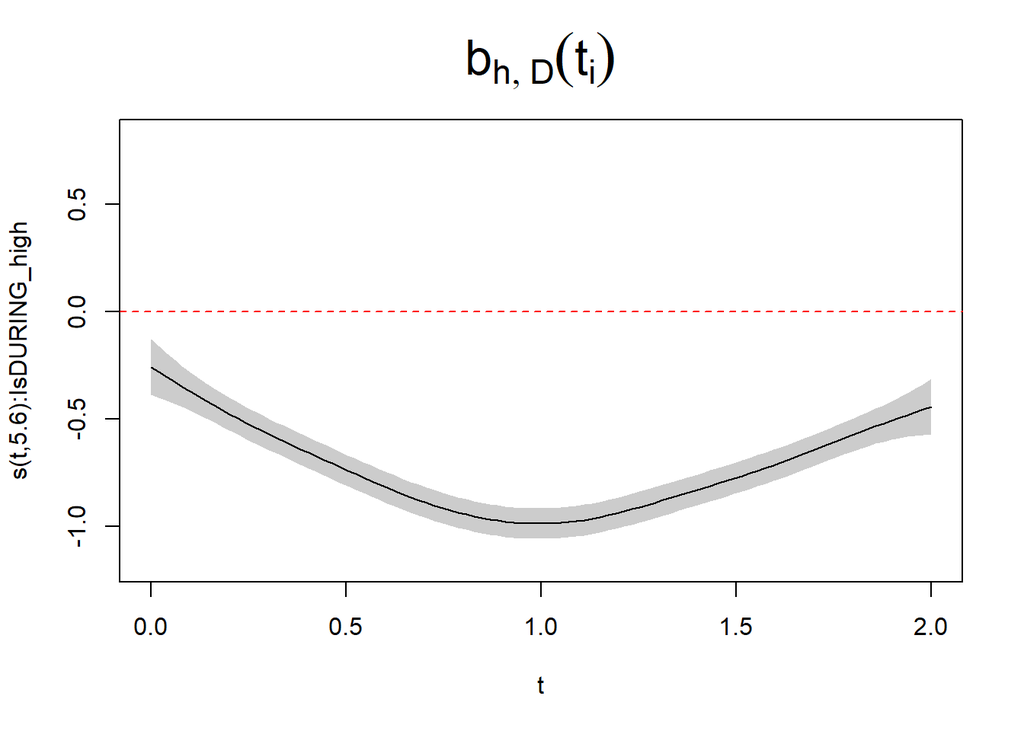

```r
plot(mod2, select = 3, shade = TRUE, rug = FALSE, main = expression(b[list(l, D)](t[i])), cex.main=2)
abline(h=0, col='red', lty=2)
plot(mod2, select = 4, shade = TRUE, rug = FALSE, main = expression(b[list(h, D)](t[i])), cex.main=2)
abline(h=0, col='red', lty=2)
```

Both binary smooths are significantly different from zero. $b_{l, D}(t_i)$ is above zero while $b_{h, D}(t_i)$ is below zero along the time axis, which is what H2 predicts.

**Important note:** some of the binary smooths in this model are defined by the same interaction conditions from the previous model. However, their value is **not** the same, as it is the **combination** of ordinary and binary smooths that defines what they actually mean.

### H3: `DURING`: `high` curves higher than `low` curves

We are lucky, as this hypothesis can be tested by reusing the model we used to test H1. We are going to check and plot $b_{D, h}(t_i)$. From the `summary` above we see that the term is significant. H3 requires this term to be above the zero line, as it represents the difference `high - low` for the `DURING` `State`.

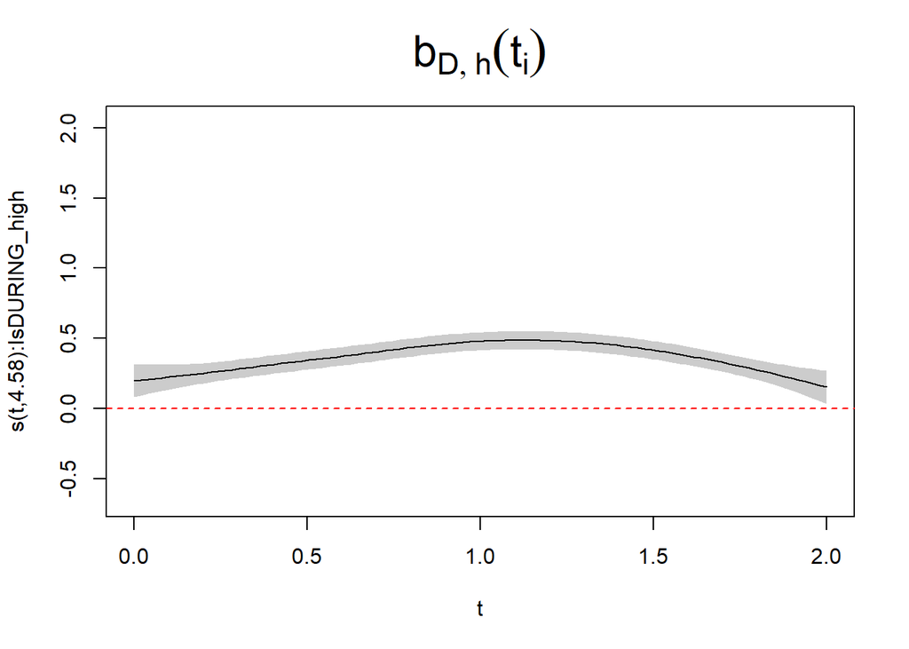

```r
plot(mod1, select = 5, shade = TRUE, rug = FALSE, main = expression(b[list(D, h)](t[i])), cex.main=2)
abline(h=0, col='red', lty=2)
```

Yes, all good.

### H4 `DURING`: `high` curves move more towards `low` curves than vice versa

This hypothesis requires a more complex structure of binary smooths. First let us express H4 in the form of an inequality:

$$(y\big\rvert_{h, B} - y\big\rvert_{h,
D}) - (y\big\rvert_{l, D} - y\big\rvert_{l, B}) > 0$$
where $y\big\rvert_{h, B}$ means “the predicted $y$ at `Category` `high` and `State` `BEFORE`”, and similarly for the other terms. That is, we are claiming that the difference curve between two difference curves has a certain sign. In order to use the mechanism of binary smooths at our advantage, we need to find a way to get just one $b$ term that models the expression on the left of the inequality above. The way we did for H1, H2 and H3 was to set base levels with ordinary $f$ smooths and then define one extra set of $b$ terms expressing differences. The $f$ terms were based on either `Category` or `State`. There are two reasons why this is not enough in our case. First, with just one set of $b$ terms we will be able to express differences between levels, but not differences of differences. So we need two sets of $b$ terms with different meanings. In particular, we need the term $y\big\rvert_{h, B} - y\big\rvert_{h, D}$ to contain one $b$ element more than the term $y\big\rvert_{l, D} - y\big\rvert_{l, B}$, so that everything cancels out and only one $b$ term remains. Second, there is no way to create the asymmetry in the subtractions that we need by using $f$ terms based on either `Category` or `State`.

Let’s tackle the latter problem first. We have to create a new factor that brings about the asymmetry we need. Let’s call it `X` and it is defined as in the picture below:

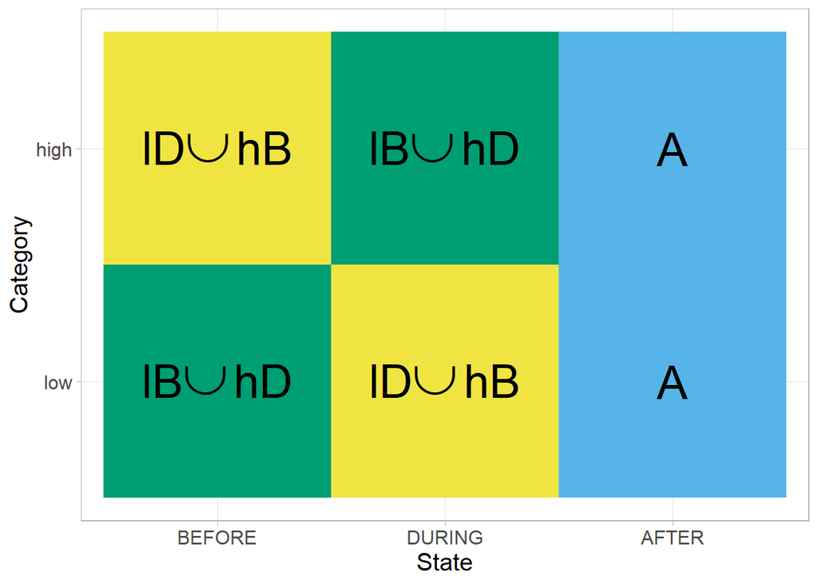

The model we are considering is the following:

$$y_i = \\
\beta_0 + \\
\beta_{lD \cup hB} \cdot I((c_i = l \cap s_i = D) \cup (c_i = h \cap s_i
= B)) + \\
\beta_{lB \cup hD} \cdot I((c_i = l \cap s_i = B) \cup (c_i = h \cap s_i
= D)) + \\
f_A(t_i) \cdot I(s_i = A) + \\
f_{lD \cup hB}(t_i) \cdot I((c_i = l \cap s_i = D) \cup (c_i = h \cap
s_i = B)) + \\
f_{lB \cup hD}(t_i) \cdot I((c_i = l \cap s_i = B) \cup (c_i = h \cap
s_i = D)) + \\
b_h(t_i) \cdot I(c_i = h) + \\
b_{lD \cup hB, h}(t_i) \cdot I(c_i = h \cap s_i = B) + \\
b_{A, h}(t_i) \cdot I(c_i = h \cap s_i = A) + \\
\epsilon_i$$

To see why this particular set up is going to solve our problem, let’s write each of the four terms in the inequality above in terms of the model (omitting the $I()$ terms and the dependency on $t_i$):

| Category | State | Inequality | Model |
| --- | --- | --- | --- |
| high | BEFORE | $y\big\rvert_{h, B}$ | $\beta_0 + \beta_{lD \cup hB} + f_{lD \cup hB} + b_h + b_{lD \cup hB, h}$ |
| high | DURING | $y\big\rvert_{h, D}$ | $\beta_0 + \beta_{lB \cup hD} + f_{lB \cup hD} + b_h$ |
| low | DURING | $y\big\rvert_{l, D}$ | $\beta_0 + \beta_{lD \cup hB} + f_{lD \cup hB}$ |
| low | BEFORE | $y\big\rvert_{l, B}$ | $\beta_0 + \beta_{lB \cup hD} + f_{lB \cup hD}$ |
| high | AFTER | - | $\beta_0 + f_A + b_h + b_{A, h}$ |
| low | AFTER | - | $\beta_0 + f_A$ |

By substituting the model terms in the inequality we can verify that only one term is left, $b_{lD \cup hB, h}$, which is what we wanted. This is a difference-of-differences curve that H4 claims to be positive. The model makes use of two types of $b$ terms, so to speak. The first type is $b_h$, which is ‘switched on’ when `Category` is `high`, while the second type is represented by $b_{lD \cup hB, h}$ and $b_{A, h}$, which are ‘switched on’ only in one `Category * State`.

The model includes also terms that have to do with the `AFTER` level, which does not play any role in the inequality describing H4. However, omitting them would be an error, as the model would not be identifying each of the six `Category` by `State` cells with a unique combination of terms. As shown in the table above, also the cells with value `AFTER` are distinguished from the others.

```r
# create category X
curves %<>%
  mutate(X = case_when(
    (Category == "low" &  State == "DURING") | (Category == "high" &  State == "BEFORE") ~ "lD_U_hB",
    (Category == "low" &  State == "BEFORE") | (Category == "high" &  State == "DURING") ~ "lB_U_hD",
    State == "AFTER" ~ "A"
  )) %>%
  mutate(X = factor(X)) # otherwise bam() "cannot find" it
# create binary variables
curves$is_h <-  1 * (curves$Category == "high")
curves$Is_lD_U_hB_h <- 1 * (curves$X == "lD_U_hB" & curves$Category == "high")
curves$Is_A_h <- 1 * (curves$X == "A" & curves$Category == "high")
# model
mod4 <- bam(y ~ X + s(t, by = X) + s(t, by = is_h) + s(t, by = Is_lD_U_hB_h) + s(t, by = Is_A_h),
          data = curves)
summary(mod4)
```

```
##
## Family: gaussian
## Link function: identity
##
## Formula:
## y ~ X + s(t, by = X) + s(t, by = is_h) + s(t, by = Is_lD_U_hB_h) +
##     s(t, by = Is_A_h)
##
## Parametric coefficients:
##             Estimate Std. Error t value Pr(>|t|)
## (Intercept)  0.85291    0.01236  69.001  < 2e-16 ***
## XlB_U_hD    -0.11336    0.01748  -6.485 9.24e-11 ***
## XlD_U_hB     0.25616    0.01748  14.654  < 2e-16 ***
## ---
## Signif. codes:  0 '***' 0.001 '**' 0.01 '*' 0.05 '.' 0.1 ' ' 1
##
## Approximate significance of smooth terms:
##                     edf Ref.df      F  p-value
## s(t):XA           5.780  6.908  69.16  < 2e-16 ***
## s(t):XlB_U_hD     5.205  6.300  44.00  < 2e-16 ***
## s(t):XlD_U_hB     5.914  7.026  76.42  < 2e-16 ***
## s(t):is_h         6.763  7.833 244.99  < 2e-16 ***
## s(t):Is_lD_U_hB_h 4.661  5.497  43.02  < 2e-16 ***
## s(t):Is_A_h       2.632  3.015  10.06 1.78e-06 ***
## ---
## Signif. codes:  0 '***' 0.001 '**' 0.01 '*' 0.05 '.' 0.1 ' ' 1
##
## R-sq.(adj) =   0.56   Deviance explained = 56.1%
## fREML =  10379  Scale est. = 0.31322   n = 12300
```

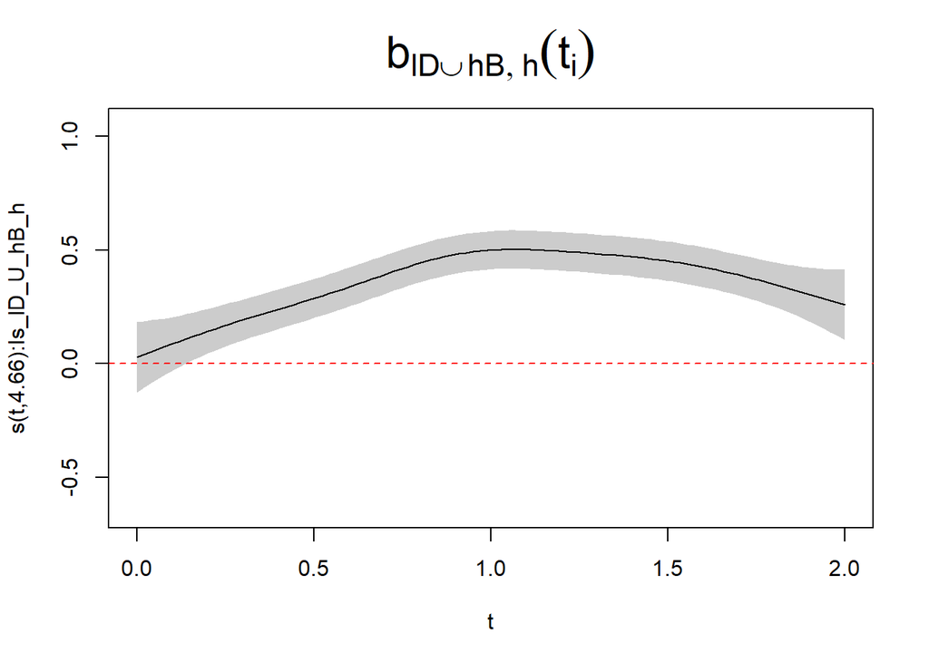

```r
plot(mod4, select = 5, shade = TRUE, rug = FALSE, main = expression(b[list(lD*union(hB), h)](t[i])), cex.main=2)
abline(h=0, col='red', lty=2)
```

Testing H4 brought two difficulties into the picture. First the need for two levels of binary smooth terms in order to express diff-of-diffs, second the need to create a new category with asymmetries in its cell composition, in order to obtain asymmetries in the signs. An example where only the first problem occurs can be found in section 4.10 of the [tutorial by Martijn Wieling](http://martijnwieling.nl/files/GAM-tutorial-Wieling.pdf). An example where a situation similar to testing H4 occurs can be found in the [supplementary materials](https://ars.els-cdn.com/content/image/1-s2.0-S0167639323000122-mmc1.pdf) of [this paper](https://www.sciencedirect.com/science/article/pii/S0167639323000122).